# EasyVisa_Full_Code_Notebook_final

### Model Building with Undersampled data

As another approach, Random UnderSampler will be used to reduce the majority 'Certified' class in the training data. Subsequently, the same set of five classification models will be trained on this newly undersampled dataset.

```
Shape of X_train_undersampled: (11846, 21)
Value counts of y_train_undersampled:  0    5923
1    5923
Name: case_status, dtype: int64
Train on undersampled data: Decision Tree
Train performance for Decision Tree (Undersampled):
   Accuracy  Recall  Precision   F1
0       1.0     1.0        1.0  1.0
```

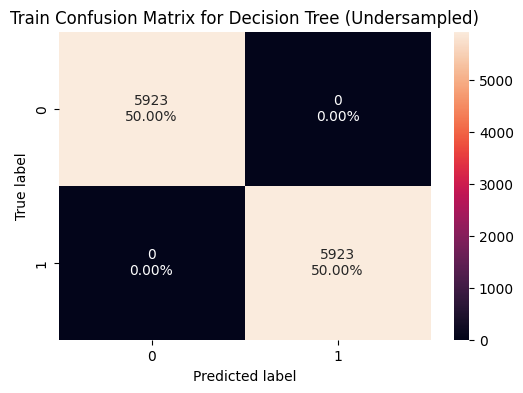

```
Test performance for Decision Tree (Undersampled):
   Accuracy    Recall  Precision        F1
0  0.630822  0.630563   0.459397  0.531541
```

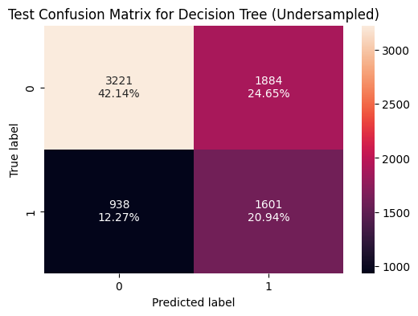

```
Train on undersampled data: Random Forest
Train performance for Random Forest (Undersampled):
   Accuracy  Recall  Precision   F1
0       1.0     1.0        1.0  1.0
```

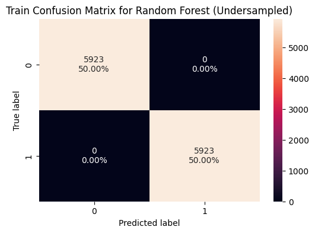

```
Test performance for Random Forest (Undersampled):
   Accuracy    Recall  Precision        F1
0  0.687206  0.687278   0.522142  0.593436
```

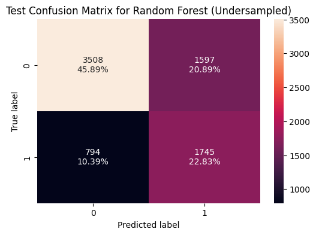

```
Train on undersampled data: Bagging Classifier
Train performance for Bagging Classifier (Undersampled):
   Accuracy    Recall  Precision        F1
0  0.979824  0.970454   0.988988  0.979634
```

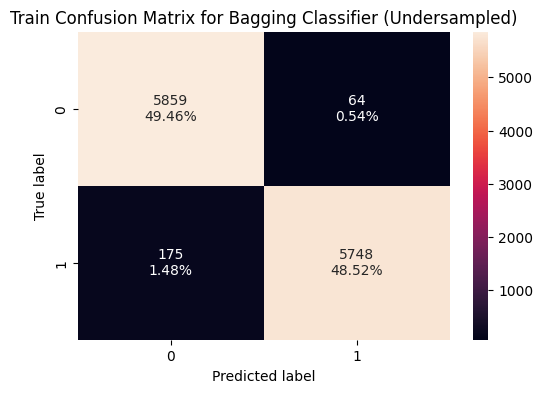

```
Test performance for Bagging Classifier (Undersampled):
   Accuracy    Recall  Precision        F1
0  0.680141  0.617566    0.51545  0.561906
```

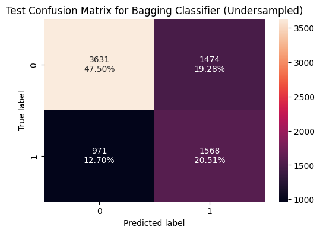

```
Train on undersampled data: AdaBoost
Train performance for AdaBoost (Undersampled):
   Accuracy    Recall  Precision        F1
0  0.690191  0.681749   0.693457  0.687553
```

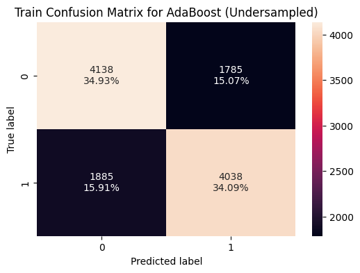

```
Test performance for AdaBoost (Undersampled):
   Accuracy    Recall  Precision        F1
0  0.701334  0.687278   0.539579  0.604538
```

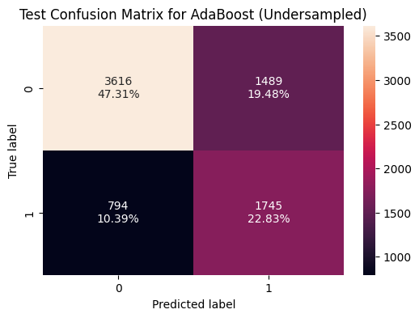

```
Train on undersampled data: Gradient Boosting
Train performance for Gradient Boosting (Undersampled):
   Accuracy    Recall  Precision        F1
0  0.711548  0.691541   0.720366  0.705659
```

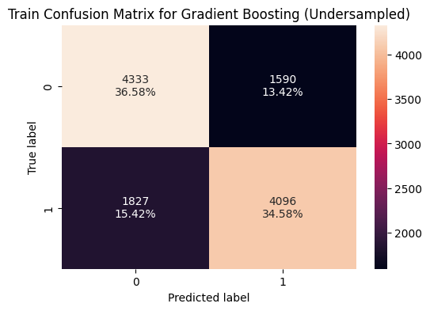

```
Test performance for Gradient Boosting (Undersampled):
   Accuracy    Recall  Precision        F1
0  0.720042  0.695156   0.563718  0.622575
```

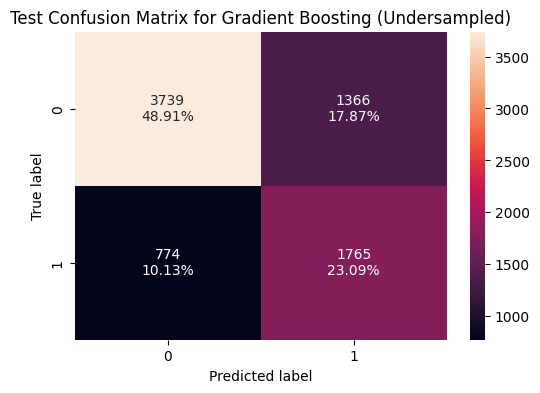

```python
random_under_sampler = RandomUnderSampler(random_state=42)
X_train_undersampled, y_train_undersampled = random_under_sampler.fit_resample(X_train, y_train)
print("Shape of X_train_undersampled:", X_train_undersampled.shape)
print("Value counts of y_train_undersampled: ", y_train_undersampled.value_counts())

undersampled_model_performance = {}
for name, model in models.items():
    print(f"Train on undersampled data: {name}")
    model.fit(X_train_undersampled, y_train_undersampled)

    train_perf = model_performance_classification_sklearn(model, X_train_undersampled, y_train_undersampled)
    print(f"Train performance for {name} (Undersampled):")
    print(train_perf)
    confusion_matrix_sklearn(model, X_train_undersampled, y_train_undersampled)
    plt.title(f'Train Confusion Matrix for {name} (Undersampled)')
    plt.show()

    test_perf = model_performance_classification_sklearn(model, X_test, y_test)
    print(f"Test performance for {name} (Undersampled):")
    print(test_perf)
    confusion_matrix_sklearn(model, X_test, y_test)
    plt.title(f'Test Confusion Matrix for {name} (Undersampled)')
    plt.show()

    undersampled_model_performance[name] = {'train': train_perf, 'test': test_perf}
    print("\n\n\n")
```

## Hyperparameter Tuning

**Best practices for hyperparameter tuning in AdaBoost:**

`n_estimators`:

- Start with a specific number (50 is used in general) and increase in steps: 50, 75, 85, 100
- Use fewer estimators (e.g., 50 to 100) if using complex base learners (like deeper decision trees)
- Use more estimators (e.g., 100 to 150) when learning rate is low (e.g., 0.1 or lower)
- Avoid very high values unless performance keeps improving on validation

`learning_rate`:

- Common values to try: 1.0, 0.5, 0.1, 0.01
- Use 1.0 for faster training, suitable for fewer estimators
- Use 0.1 or 0.01 when using more estimators to improve generalization
- Avoid very small values (< 0.01) unless you plan to use many estimators (e.g., >500) and have sufficient data

**Best practices for hyperparameter tuning in Random Forest:**

`n_estimators`:

- Start with a specific number (50 is used in general) and increase in steps: 50, 75, 100, 125
- Higher values generally improve performance but increase training time
- Use 100-150 for large datasets or when variance is high

`min_samples_leaf`:

- Try values like: 1, 2, 4, 5, 10
- Higher values reduce model complexity and help prevent overfitting
- Use 1–2 for low-bias models, higher (like 5 or 10) for more regularized models
- Works well in noisy datasets to smooth predictions

`max_features`:

- Try values: `"sqrt"` (default for classification), `"log2"`, `None`, or float values (e.g., `0.3`, `0.5`)
- `"sqrt"` balances between diversity and performance for classification tasks
- Lower values (e.g., `0.3`) increase tree diversity, reducing overfitting
- Higher values (closer to `1.0`) may capture more interactions but risk overfitting

`max_samples` (for bootstrap sampling):

- Try float values between `0.5` to `1.0` or fixed integers
- Use `0.6–0.9` to introduce randomness and reduce overfitting
- Smaller values increase diversity between trees, improving generalization

**Best practices for hyperparameter tuning in Gradient Boosting:**

`n_estimators`:

- Start with 100 (default) and increase: 100, 200, 300, 500
- Typically, higher values lead to better performance, but they also increase training time
- Use 200–500 for larger datasets or complex problems
- Monitor validation performance to avoid overfitting, as too many estimators can degrade generalization

`learning_rate`:

- Common values to try: 0.1, 0.05, 0.01, 0.005
- Use lower values (e.g., 0.01 or 0.005) if you are using many estimators (e.g., > 200)
- Higher learning rates (e.g., 0.1) can be used with fewer estimators for faster convergence
- Always balance the learning rate with `n_estimators` to prevent overfitting or underfitting

`subsample`:

- Common values: 0.7, 0.8, 0.9, 1.0
- Use a value between `0.7` and `0.9` for improved generalization by introducing randomness
- `1.0` uses the full dataset for each boosting round, potentially leading to overfitting
- Reducing `subsample` can help reduce overfitting, especially in smaller datasets

`max_features`:

- Common values: `"sqrt"`, `"log2"`, or float (e.g., `0.3`, `0.5`)
- `"sqrt"` (default) works well for classification tasks
- Lower values (e.g., `0.3`) help reduce overfitting by limiting the number of features considered at each split

**Best practices for hyperparameter tuning in XGBoost:**

`n_estimators`:

- Start with 50 and increase in steps: 50,75,100,125.
- Use more estimators (e.g., 150-250) when using lower learning rates
- Monitor validation performance
- High values improve learning but increase training time

`subsample`:

- Common values: 0.5, 0.7, 0.8, 1.0
- Use `0.7–0.9` to introduce randomness and reduce overfitting
- `1.0` uses the full dataset in each boosting round; may overfit on small datasets
- Values < 0.5 are rarely useful unless dataset is very large

`gamma`:

- Try values: 0 (default), 1, 3, 5, 8
- Controls minimum loss reduction needed for a split
- Higher values make the algorithm more conservative (i.e., fewer splits)
- Use values > 0 to regularize and reduce overfitting, especially on noisy data

`colsample_bytree`:

- Try values: 0.3, 0.5, 0.7, 1.0
- Fraction of features sampled per tree
- Lower values (e.g., 0.3 or 0.5) increase randomness and improve generalization
- Use `1.0` when you want all features considered for every tree

`colsample_bylevel`:

- Try values: 0.3, 0.5, 0.7, 1.0
- Fraction of features sampled at each tree level (i.e., per split depth)
- Lower values help in regularization and reducing overfitting
- Often used in combination with `colsample_bytree` for fine control over feature sampling

```
GridSearchCV for Random Forest
Fitting 5 folds for each of 16 candidates, totalling 80 fits
```

```
Top parameters for Random Forest (Oversampled): {'max_depth': 10, 'max_features': 0.7, 'min_samples_leaf': 2, 'n_estimators': 100}

Performance of Tuned Random Forest (Oversampled) on Test Set:
   Accuracy    Recall  Precision        F1
0  0.743721  0.576605   0.623509  0.599141
```

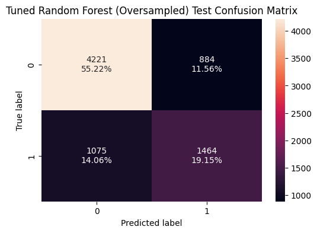

```python
# Tuned Random Forest
param_grid_random_forest = {
    'n_estimators': [50, 100],
    'max_depth': [10, 15],
    'min_samples_leaf': [1, 2],
    'max_features': ['sqrt', 0.7]
}

random_forest_classifier = RandomForestClassifier(random_state=42)
print("GridSearchCV for Random Forest")
grid_search_random_forest = GridSearchCV(estimator=random_forest_classifier, param_grid=param_grid_random_forest, cv=StratifiedKFold(n_splits=5), scoring=scorer, n_jobs=-1, verbose=1)
grid_search_random_forest.fit(X_train_oversampled, y_train_oversampled)

print("\nTop parameters for Random Forest (Oversampled):", grid_search_random_forest.best_params_)
tuned_random_forest = grid_search_random_forest.best_estimator_

print("\nPerformance of Tuned Random Forest (Oversampled) on Test Set:")
tuned_random_forest_perf = model_performance_classification_sklearn(tuned_random_forest, X_test, y_test)
print(tuned_random_forest_perf)
confusion_matrix_sklearn(tuned_random_forest, X_test, y_test)
plt.title('Tuned Random Forest (Oversampled) Test Confusion Matrix')
plt.show()
```

```
GridSearchCV for AdaBoost
Fitting 5 folds for each of 4 candidates, totalling 20 fits
\Top parameters for AdaBoost (Oversampled): {'estimator__max_depth': 1, 'learning_rate': 0.5, 'n_estimators': 50}

Performance of Tuned AdaBoost (Oversampled) on Test Set:
   Accuracy    Recall  Precision      F1
0  0.666536  0.642773   0.498473  0.5615
```

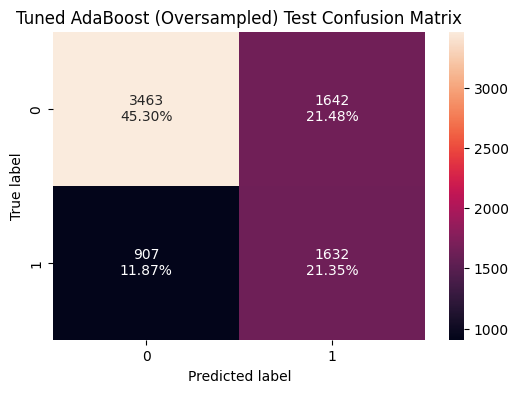

```python
# Tuned AdaBoost
param_grid_ada_boost = {
    'n_estimators': [50, 75],
    'learning_rate': [0.5, 1.0],
    'estimator__max_depth': [1]
}


ada_boost_classifier = AdaBoostClassifier(estimator=DecisionTreeClassifier(random_state=42), random_state=42, algorithm='SAMME')
print("\nGridSearchCV for AdaBoost")
grid_search_ada_boost = GridSearchCV(estimator=ada_boost_classifier, param_grid=param_grid_ada_boost, cv=StratifiedKFold(n_splits=5), scoring=scorer, n_jobs=-1, verbose=1)
grid_search_ada_boost.fit(X_train_oversampled, y_train_oversampled)

print("\Top parameters for AdaBoost (Oversampled):", grid_search_ada_boost.best_params_)
tuned_ada_boost = grid_search_ada_boost.best_estimator_

print("\nPerformance of Tuned AdaBoost (Oversampled) on Test Set:")
tuned_ada_boost_perf = model_performance_classification_sklearn(tuned_ada_boost, X_test, y_test)
print(tuned_ada_boost_perf)
confusion_matrix_sklearn(tuned_ada_boost, X_test, y_test)
plt.title('Tuned AdaBoost (Oversampled) Test Confusion Matrix')
plt.show()
```

```
GridSearchCV for Gradient Boosting
Fitting 5 folds for each of 16 candidates, totalling 80 fits
```

```
Top parameters for Gradient Boosting (Oversampled): {'learning_rate': 0.05, 'max_features': 0.7, 'n_estimators': 100, 'subsample': 0.9}

Performance of Tuned Gradient Boosting (Oversampled) on Test Set:
   Accuracy    Recall  Precision        F1
0  0.736918  0.597479   0.605347  0.601388
```

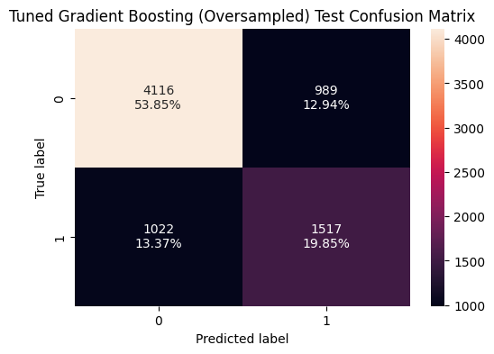

```python
# Tuned Gradient Boosting
param_grid_gradient_boosting = {
    'n_estimators': [100, 200],
    'learning_rate': [0.05, 0.1],
    'max_features': ['sqrt', 0.7],
    'subsample': [0.8, 0.9]
}

gradient_boosting_classifier = GradientBoostingClassifier(random_state=42)
print("\nGridSearchCV for Gradient Boosting")
grid_search_gradient_boosting = GridSearchCV(estimator=gradient_boosting_classifier, param_grid=param_grid_gradient_boosting, cv=StratifiedKFold(n_splits=5), scoring=scorer, n_jobs=-1, verbose=1)
grid_search_gradient_boosting.fit(X_train_oversampled, y_train_oversampled)

print("\nTop parameters for Gradient Boosting (Oversampled):", grid_search_gradient_boosting.best_params_)
tuned_gradient_boosting = grid_search_gradient_boosting.best_estimator_

print("\nPerformance of Tuned Gradient Boosting (Oversampled) on Test Set:")
tuned_gradient_boosting_perf = model_performance_classification_sklearn(tuned_gradient_boosting, X_test, y_test)
print(tuned_gradient_boosting_perf)
confusion_matrix_sklearn(tuned_gradient_boosting, X_test, y_test)
plt.title('Tuned Gradient Boosting (Oversampled) Test Confusion Matrix')
plt.show()
```

```
Top XGBoost params: {'learning_rate': 0.05, 'max_depth': 3, 'n_estimators': 100}
```

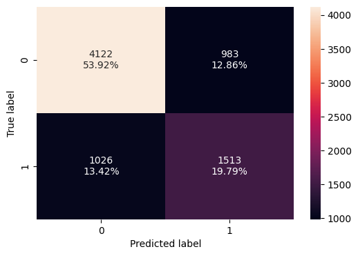

```python
# XGBoost
xgb_param_grid = {
    'n_estimators': [100, 200],
    'max_depth': [3, 5],
    'learning_rate': [0.05, 0.1]
}

xgb_clf = XGBClassifier(random_state=42, use_label_encoder=False, eval_metric='logloss')

grid_search_xgb = GridSearchCV(
    estimator=xgb_clf,
    param_grid=xgb_param_grid,
    cv=5,
    scoring=scorer,
    n_jobs=-1
)

grid_search_xgb.fit(X_train_oversampled, y_train_oversampled)

best_xgb = grid_search_xgb.best_estimator_
print("Top XGBoost params:", grid_search_xgb.best_params_)

xgb_perf = model_performance_classification_sklearn(best_xgb, X_test, y_test)
confusion_matrix_sklearn(best_xgb, X_test, y_test)
```

```
Top Gradient Boosting params: {'learning_rate': 0.05, 'max_depth': 3, 'n_estimators': 100}
```

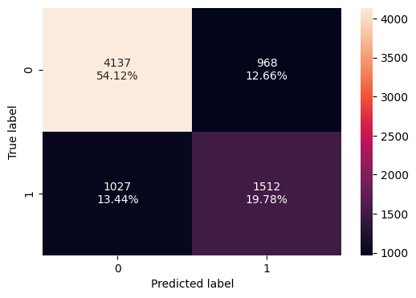

```python
# Gradient Boosting
gradien_boosting_param_grid = {
    'n_estimators': [100, 150],
    'learning_rate': [0.05, 0.1],
    'max_depth': [3, 4]
}

gradien_boosting_clf = GradientBoostingClassifier(random_state=42)

grid_search_gradien_boosting = GridSearchCV(
    estimator=gradien_boosting_clf,
    param_grid=gradien_boosting_param_grid,
    cv=5,
    scoring=scorer,
    n_jobs=-1
)

grid_search_gradien_boosting.fit(X_train_oversampled, y_train_oversampled)

best_gradien_boosting = grid_search_gradien_boosting.best_estimator_
print("Top Gradient Boosting params:", grid_search_gradien_boosting.best_params_)

gradien_boosting_perf = model_performance_classification_sklearn(best_gradien_boosting, X_test, y_test)

confusion_matrix_sklearn(best_gradien_boosting, X_test, y_test)
```

## Model Performance Summary and Final Model Selection

```
Models Performance:

                               Model Name      Training Data    Recall  \
9        Gradient Boosting (Undersampled)       Undersampled  0.695156
6            Random Forest (Undersampled)       Undersampled  0.687278
8                 AdaBoost (Undersampled)       Undersampled  0.687278
17           Tuned AdaBoost (Oversampled)  Tuned Oversampled  0.642773
5            Decision Tree (Undersampled)       Undersampled  0.630563
7       Bagging Classifier (Undersampled)       Undersampled  0.617566
16  Tuned Gradient Boosting (Oversampled)  Tuned Oversampled  0.597479
14        Gradient Boosting (Oversampled)        Oversampled  0.580150
15      Tuned Random Forest (Oversampled)  Tuned Oversampled  0.576605
13                 AdaBoost (Oversampled)        Oversampled  0.575030
11            Random Forest (Oversampled)        Oversampled  0.540370
10            Decision Tree (Oversampled)        Oversampled  0.519102
4                       Gradient Boosting           Original  0.498228
0                           Decision Tree           Original  0.496258
1                           Random Forest           Original  0.483261
12       Bagging Classifier (Oversampled)        Oversampled  0.479716
3                                AdaBoost           Original  0.446239
2                      Bagging Classifier           Original  0.419063

    Accuracy  Precision  F1-Score
9   0.720042   0.563718  0.622575
6   0.687206   0.522142  0.593436
8   0.701334   0.539579  0.604538
17  0.666536   0.498473  0.561500
5   0.630822   0.459397  0.531541
7   0.680141   0.515450  0.561906
16  0.736918   0.605347  0.601388
14  0.736525   0.608426  0.593952
15  0.743721   0.623509  0.599141
13  0.691654   0.533236  0.553345
11  0.723443   0.591634  0.564841
10  0.655939   0.483315  0.500570
4   0.753401   0.674307  0.573046
0   0.649529   0.473684  0.484709
1   0.727760   0.614729  0.541125
12  0.704474   0.564935  0.518850
3   0.742151   0.667256  0.534812
2   0.712585   0.595745  0.492023

Selected Model Name: Gradient Boosting (Undersampled)
Training Data for Training: Undersampled
Performance of Selected Model: , Model Name       Gradient Boosting (Undersampled)
Training Data                        Undersampled
Recall                                   0.695156
Accuracy                                 0.720042
Precision                                0.563718
F1-Score                                 0.622575
Name: 9, dtype: object

Confusion Matrix for the selected Model
```

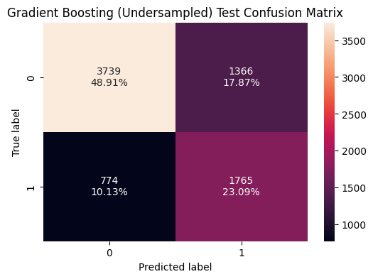

```python
models_df = pd.DataFrame(columns=['Model Name', 'Training Data', 'Recall', 'Accuracy', 'Precision', 'F1-Score'])

def add_entry(df, model_name, training_data, performance_df):
    new_row = {'Model Name': model_name,
           'Training Data': training_data,
           'Recall': performance_df['Recall'].iloc[0],
           'Accuracy': performance_df['Accuracy'].iloc[0],
           'Precision': performance_df['Precision'].iloc[0],
           'F1-Score': performance_df['F1'].iloc[0]}
    return pd.concat([df, pd.DataFrame([new_row])], ignore_index=True)

# Original model performance
for name, perf_dict in original_model_performance.items():
    models_df = add_entry(models_df, name, 'Original', perf_dict['test'])

# Undersampled model performance
for name, perf_dict in undersampled_model_performance.items():
    models_df = add_entry(models_df, name + ' (Undersampled)', 'Undersampled', perf_dict['test'])

# Oversampled model performance
for name, perf_dict in oversampled_model_performance.items():
    models_df = add_entry(models_df, name + ' (Oversampled)', 'Oversampled', perf_dict['test'])

# Tuned model performance
models_df = add_entry(models_df, 'Tuned Random Forest (Oversampled)', 'Tuned Oversampled', tuned_random_forest_perf)
models_df = add_entry(models_df, 'Tuned Gradient Boosting (Oversampled)', 'Tuned Oversampled', tuned_gradient_boosting_perf)
models_df = add_entry(models_df, 'Tuned AdaBoost (Oversampled)', 'Tuned Oversampled', tuned_ada_boost_perf)

print("Models Performance:\n")
print(models_df.sort_values(by='Recall', ascending=False))

selected_model_entry = models_df.sort_values(by='Recall', ascending=False).iloc[0]
selected_model_name = selected_model_entry['Model Name']
selected_model_training_data = selected_model_entry['Training Data']

print(f"\nSelected Model Name: {selected_model_name}")
print(f"Training Data for Training: {selected_model_training_data}")
print(f"Performance of Selected Model: , {selected_model_entry}")

if selected_model_name == 'Tuned Random Forest (Oversampled)':
    selected_model = tuned_random_forest
elif selected_model_name == 'Tuned AdaBoost (Oversampled)':
    selected_model = tuned_ada_boost
elif selected_model_name == 'Tuned Gradient Boosting (Oversampled)':
    selected_model = tuned_gradient_boosting_perf
elif 'Oversampled' in selected_model_name:
    original_model_name = selected_model_name.replace(' (Oversampled)', '')
    selected_model = models[original_model_name]
    if original_model_name == 'Decision Tree':
        selected_model.fit(X_train_oversampled, y_train_oversampled)
    elif original_model_name == 'Random Forest':
        selected_model.fit(X_train_oversampled, y_train_oversampled)
    elif original_model_name == 'AdaBoost':
        selected_model.fit(X_train_oversampled, y_train_oversampled)
    elif original_model_name == 'Bagging Classifier':
        selected_model.fit(X_train_oversampled, y_train_oversampled)
    elif original_model_name == 'Gradient Boosting':
        selected_model.fit(X_train_oversampled, y_train_oversampled)
elif 'Undersampled' in selected_model_name:
    original_model_name = selected_model_name.replace(' (Undersampled)', '')
    selected_model = models[original_model_name]
    if original_model_name == 'Decision Tree':
        selected_model.fit(X_train_undersampled, y_train_undersampled)
    elif original_model_name == 'Random Forest':
        selected_model.fit(X_train_undersampled, y_train_undersampled)
    elif original_model_name == 'AdaBoost':
        selected_model.fit(X_train_undersampled, y_train_undersampled)
    elif original_model_name == 'Bagging Classifier':
        selected_model.fit(X_train_undersampled, y_train_undersampled)
    elif original_model_name == 'Gradient Boosting':
        selected_model.fit(X_train_undersampled, y_train_undersampled)
else:
    selected_model = models[selected_model_name]
    selected_model.fit(X_train, y_train)

print("\nConfusion Matrix for the selected Model")
confusion_matrix_sklearn(selected_model, X_test, y_test)
plt.title(f'{selected_model_name} Test Confusion Matrix')
plt.show()
```

The Gradient Boosting model, specifically when trained with undersampled data, came out on top. It achieved the highest 'Recall' score, hitting almost 70%. It's really good at catching most of the applications that should be certified.

What's interesting is that balancing the dataset by undersampling the 'Certified' cases actually made a bigger difference in finding those certifiable applications than just fine-tuning the models' settings. While this model is excellent at identifying positives, it's worth noting that its 'Precision' is a bit lower than some others. To make sure we don't miss many certifiable cases, the model might occasionally flag a 'Denied' case as 'Certified' by mistake. But for our main goal of speeding up approvals, that high 'Recall' is needed.

To sum it up, this model is a powerful tool to automatically identify a large portion of likely-to-be-certified applications, significantly cutting down the manual workload. But we'll still need human reviewers for those 'false alarms' and to double-check the cases the model might have wrongly pushed towards 'Denied' status.

## Actionable Insights and Recommendations

It's clear that education and work experience are huge for getting a visa certified. If someone has a Master's or Bachelor's degree, plus some job experience, their chances of approval increase. It really seems like practical skills and good qualifications are what the system is looking for.

There are also some interesting geographic patterns. While a lot of applicants come from Asia and get certified, applicants from Europe and Africa actually have the highest success rates. And in the US, places like the Midwest and the Islands tend to offer higher wages.

Wages and job types also play a big role. Applications for higher-paying, full-time jobs, especially those paid yearly, are more likely to get certified. This makes sense, as it aligns with the goal of ensuring foreign workers are paid fairly and have stable positions.

The data itself has many more 'Certified' cases than 'Denied' ones. To handle this, 'undersampling' the certified cases was actually the most effective way to train our models. It helped the models get much better at identifying those 'Certified' applications, which is the main goal.

Speaking of models, the Gradient Boosting model, specifically when trained with that undersampled data, was the star performer. It can correctly identify almost 70% of the applications that should be certified.

Of course, no model is perfect. While it's great at finding certified cases, it will sometimes flag a 'Denied' case as 'Certified' by mistake ('false positive'). And, occasionally, it might miss a truly 'Certified' case, labeling it as 'Denied' (a 'false negative').

Based on all this, here are some practical steps:

- Fast-Track the Strong Candidates: Let's set up a quick review lane for applications from people with higher degrees and solid work experience. They're statistically more likely to be approved anyway, so we can speed up their process.
- Use the Model for Smart Pre-screening: Deploying this Gradient Boosting model will help sort applications automatically.
- 'Auto-Approve' Stream: If the model is super confident an application will be certified, we can automatically push it through for expedited approval. This will drastically cut down on manual checks.
- 'Human Review' Queue: Applications that the model flags as 'Denied' or those it's less sure about should still go straight to a human reviewer. This ensures we don't miss any qualified applicants or accidentally approve problematic ones.
- Help applicants: Let's provide clearer guidance to employers and foreign workers. We can highlight that higher education, solid job experience, competitive wages, and full-time positions significantly boost their chances of approval. This should lead to better applications.
- Keep updating the model: This way, it stays accurate and useful over time.

Power Ahead

```python
%%shell
jupyter nbconvert --to html '/content/drive/MyDrive/Colab Notebooks/EasyVisa_Full_Code_Notebook_final.ipynb'
```

```
[NbConvertApp] Converting notebook /content/drive/MyDrive/Colab Notebooks/EasyVisa_Full_Code_Notebook_final.ipynb to html
[NbConvertApp] WARNING | Alternative text is missing on 44 image(s).
[NbConvertApp] Writing 2138616 bytes to /content/drive/MyDrive/Colab Notebooks/EasyVisa_Full_Code_Notebook_final.html
```